# P5.1 - Construction de l'échantillon

# Table des matières

```python
# Import des librairies
import numpy as np
import pandas as pd

import matplotlib.pyplot as plt   # visualizations
import seaborn as sns             # visualizations

%matplotlib inline
```

```python
# sépatateurs milliers = , et une décimale
pd.options.display.float_format = '{:,.1f}'.format
```

## Variables minimales requises

### population 2013, variation 2008-2013

```python
# import des données 'population_2003_2008_2013'
pop = pd.read_csv('data/population_2008_2013.csv')
pop.head(1)
```

|  | Domain Code | Domain | Country Code | Country | Element Code | Element | Item Code | Item | Year Code | Year | Unit | Value | Flag | Flag Description |
| --- | --- | --- | --- | --- | --- | --- | --- | --- | --- | --- | --- | --- | --- | --- |
| 0 | FBS | Food Balance Sheets | 2 | Afghanistan | 511 | Total Population - Both sexes | 2501 | Population | 2008 | 2008 | 1000 persons | 27032 | NaN | Official data |

#### Wrangling et sélection des variables

```python
# on exclut l'agrégat "China" :
pop = pop[(pop['Country'] != "China")]

# on  divise 'population' par 1000 pour l'exprimer en millions
pop['Value'] = pop['Value'] / 1000

# copie sélective
pop_clean = pop[['Country Code','Country','Year','Value']].copy()

# on renomme les variables de pop_clean
pop_clean.columns = ['ctry_cd','country','year','population']
pop_clean.head(1)
```

|  | ctry_cd | country | year | population |
| --- | --- | --- | --- | --- |
| 0 | 2 | Afghanistan | 2008 | 27.0 |

```python
# pivot sur 'year'
data = pop_clean.pivot_table(
    index=['ctry_cd','country'],
    columns = ['year'], values=['population'], aggfunc=sum)
data.columns = ['pop_2008', 'pop_2013']
data = data.reset_index()
data.count()
```

```
ctry_cd     176
country     176
pop_2008    175
pop_2013    174
dtype: int64
```

#### Traitement des NaN

```python
# recherche de NaN
na = data[data.isnull().any(axis=1)]
na
```

|  | ctry_cd | country | pop_2008 | pop_2013 |
| --- | --- | --- | --- | --- |
| 108 | 151 | Netherlands Antilles (former) | 0.2 | nan |
| 142 | 206 | Sudan (former) | 41.4 | nan |
| 175 | 276 | Sudan | nan | 38.0 |

- [Antilles néerlandaises](https://fr.wikipedia.org/wiki/Dissolution_de_la_f%C3%A9d%C3%A9ration_des_Antilles_n%C3%A9erlandaises): Les Antilles néerlandaises sont dissoutes dans le cadre de la réforme étatique du Royaume des Pays-Bas du 10 octobre 2010 sous l'effet de l’amendement du statut du Royaume des Pays-Bas.
- Le référendum d'autodétermination du Soudan du Sud a eu lieu 9 janvier 2011, le Soudan (206) en tant qu'état n'existe plus. Après avoir tenté de concaténer les ctry_cd 206 et 276, il s'avère qu'il est préférable de retirer ce pays au vu de son l'instabilité sociale. politique et économique

```python
# supression des lignes NaN
data = data.dropna()
data.count()
```

```
ctry_cd     173
country     173
pop_2008    173
pop_2013    173
dtype: int64
```

```python
# Création d'un df-key pour 'ctry_cd' et 'country'
ctrykey = data[['ctry_cd','country']].copy()
ctrykey.head(2)
```

|  | ctry_cd | country |
| --- | --- | --- |
| 0 | 1 | Armenia |
| 1 | 2 | Afghanistan |

```python
ctrykey.count()
```

```
ctry_cd    173
country    173
dtype: int64
```

#### Création du ratio 'pop_var 2008-2013'

```python
# création de la variable 'pop_var'
data['pop_var'] = data['pop_2013'] / data['pop_2008'] * 100

# copie sélective
deltpop = data[['ctry_cd','country','pop_2013','pop_var']].copy()
deltpop[['pop_2013','pop_var']].describe()
```

|  | pop_2013 | pop_var |
| --- | --- | --- |
| count | 173.0 | 173.0 |
| mean | 40.2 | 107.2 |
| std | 146.0 | 6.7 |
| min | 0.1 | 95.9 |
| 25% | 2.3 | 102.7 |
| 50% | 9.4 | 106.5 |
| 75% | 27.8 | 110.7 |
| max | 1,385.6 | 140.0 |

```python
# population mondiale 2013 (millions)
round(deltpop['pop_2013'].sum(),3)
```

```
6959.362
```

### Ratio protéines animales vs total protéines

#### Wrangling et sélection des variables

```python
# import du df du P3 ex3 'food_supply_prot_ctry'
prot = pd.read_csv('data/food_supply_prot_ctry.csv')

# on renomme Protein supply (kg/ctry/y)'
prot.rename(columns={'Protein supply (kg/ctry/y)':'prot_kg_y'}, inplace=True)

# groupby et somme
prot2 = prot.groupby(['ctry_cd','origin']).prot_kg_y.sum()
prot2 = prot2.reset_index()
prot2.head(2)
```

|  | ctry_cd | origin | prot_kg_y |
| --- | --- | --- | --- |
| 0 | 1 | animal | 46,984,800.2 |
| 1 | 1 | vegetal | 50,874,846.1 |

```python
# pivot sur 'origin'
protani = prot2.pivot_table(index=['ctry_cd'],columns = ['origin'], values=['prot_kg_y'], aggfunc=sum)
protani.columns = ['prot_ani', 'prot_veg']
protani = protani.reset_index()
protani.head(2)
```

|  | ctry_cd | prot_ani | prot_veg |
| --- | --- | --- | --- |
| 0 | 1 | 46,984,800.2 | 50,874,846.1 |
| 1 | 2 | 136,159,570.8 | 513,525,654.0 |

#### création de la variable 'prot_ani_ratio'

```python
# création de la colomne 'prot_ani_ratio'
protani['prot_ani_ratio'] = protani['prot_ani'] / (protani['prot_ani'] + protani['prot_veg'])  * 100
# On ne garde que les variables utiles
protani.drop(['prot_ani', 'prot_veg'], axis=1, inplace = True)
protani.head(2)
```

|  | ctry_cd | prot_ani_ratio |
| --- | --- | --- |
| 0 | 1 | 48.0 |
| 1 | 2 | 21.0 |

```python
# merge de protani et ctrykey
aniratio = pd.merge(protani,ctrykey, on=['ctry_cd'], how='outer')
#aniratio = aniratio.reset_index()
aniratio.head(2)
```

|  | ctry_cd | prot_ani_ratio | country |
| --- | --- | --- | --- |
| 0 | 1 | 48.0 | Armenia |
| 1 | 2 | 21.0 | Afghanistan |

```python
aniratio['prot_ani_ratio'].describe()
```

```
count   174.0
mean     42.8
std      16.2
min       9.8
25%      28.6
50%      45.1
75%      56.5
max      73.1
Name: prot_ani_ratio, dtype: float64
```

### Disponibilité alimentaire en protéines et en calories par habitant

#### Wrangling et sélection des variables

```python
# Import du df du P3 ex3 'data_p3q3'
datapc = pd.read_csv('data/data_p3q3.csv')
datapc.head(1)
```

|  | ctry_cd | country | item_cd | item | origin | population | Domestic supply quantity | Export Quantity | Fat supply quantity (g/capita/day) | Feed | ... | Food supply (kcal/capita/day) | Food supply quantity (kg/capita/yr) | Import Quantity | Losses | Other uses | Processing | Production | Protein supply quantity (g/capita/day) | Seed | Stock Variation |
| --- | --- | --- | --- | --- | --- | --- | --- | --- | --- | --- | --- | --- | --- | --- | --- | --- | --- | --- | --- | --- | --- |
| 0 | 1 | Armenia | 2511 | Wheat and products | vegetal | 2977000 | 554.0 | 1.0 | 3.6 | 93.0 | ... | 1,024.0 | 130.6 | 361.0 | 32.0 | 0.0 | 10.0 | 312.0 | 30.5 | 30.0 | -118.0 |

1 rows × 21 columns

```python
# copie sélective
dapc = datapc[['ctry_cd','country','Food supply (kcal/capita/day)','Protein supply quantity (g/capita/day)']].copy()
# On renomme les variables
dapc.rename(columns={'Food supply (kcal/capita/day)': 'food_kcal_cap_day',
                     'Protein supply quantity (g/capita/day)': 'prot_g_cap_day'},
            inplace=True)
dapc.head(2)
```

|  | ctry_cd | country | food_kcal_cap_day | prot_g_cap_day |
| --- | --- | --- | --- | --- |
| 0 | 1 | Armenia | 1,024.0 | 30.5 |
| 1 | 1 | Armenia | 0.0 | 0.0 |

#### création du dataset 'prot_g_cap_day'

```python
# groupby et somme de 'Prot_g_cap_day'
dapcprot = dapc.groupby(['ctry_cd','country']).prot_g_cap_day.sum()
dapcprot = dapcprot.reset_index()
dapcprot.head(2)
```

|  | ctry_cd | country | prot_g_cap_day |
| --- | --- | --- | --- |
| 0 | 1 | Armenia | 90.1 |
| 1 | 2 | Afghanistan | 58.3 |

```python
dapcprot.count()
```

```
ctry_cd           174
country           174
prot_g_cap_day    174
dtype: int64
```

#### Création du df disponibilité alimentaire

```python
# groupby et somme de 'food_kcal_cap_day'
dapckcal = dapc.groupby(['ctry_cd']).food_kcal_cap_day.sum()
dapckcal = dapckcal.reset_index()
dapckcal.head(2)
```

|  | ctry_cd | food_kcal_cap_day |
| --- | --- | --- |
| 0 | 1 | 2,924.0 |
| 1 | 2 | 2,087.0 |

```python
dapckcal.count()
```

```
ctry_cd              174
food_kcal_cap_day    174
dtype: int64
```

```python
# merge de dapcprot et dapckcal
dispalim = pd.merge(dapcprot,dapckcal, on=['ctry_cd'], how='outer')
dispalim.head(2)
```

|  | ctry_cd | country | prot_g_cap_day | food_kcal_cap_day |
| --- | --- | --- | --- | --- |
| 0 | 1 | Armenia | 90.1 | 2,924.0 |
| 1 | 2 | Afghanistan | 58.3 | 2,087.0 |

```python
dispalim.count()
```

```
ctry_cd              174
country              174
prot_g_cap_day       174
food_kcal_cap_day    174
dtype: int64
```

### Consolidation des tables et export

#### Rappel des df population, protani et dsiponibilité alimentaire

```python
# population 1.1
deltpop.head(1)
```

|  | ctry_cd | country | pop_2013 | pop_var |
| --- | --- | --- | --- | --- |
| 0 | 1 | Armenia | 3.0 | 100.0 |

```python
deltpop.count()
```

```
ctry_cd     173
country     173
pop_2013    173
pop_var     173
dtype: int64
```

```python
# ratio prot amimales
aniratio.head(2)
```

|  | ctry_cd | prot_ani_ratio | country |
| --- | --- | --- | --- |
| 0 | 1 | 48.0 | Armenia |
| 1 | 2 | 21.0 | Afghanistan |

```python
aniratio.count()
```

```
ctry_cd           174
prot_ani_ratio    174
country           173
dtype: int64
```

```python
# disponibilité alimentaire en prot/g/cap/day et en kcal/cap/day
dispalim.head(1)
```

|  | ctry_cd | country | prot_g_cap_day | food_kcal_cap_day |
| --- | --- | --- | --- | --- |
| 0 | 1 | Armenia | 90.1 | 2,924.0 |

```python
dispalim.count()
```

```
ctry_cd              174
country              174
prot_g_cap_day       174
food_kcal_cap_day    174
dtype: int64
```

#### Merge des 3 df

```python
# méthode de groupement rapide trouvé ici :
# https://stackoverflow.com/questions/23668427/pandas-three-way-joining-multiple-dataframes-on-columns
from functools import reduce
dfs = [deltpop, aniratio, dispalim]
dfmini = reduce(lambda left,right: pd.merge(left,right,on=['ctry_cd','country'], how='outer'), dfs)
dfmini.reset_index()
dfmini.head(2)
```

|  | ctry_cd | country | pop_2013 | pop_var | prot_ani_ratio | prot_g_cap_day | food_kcal_cap_day |
| --- | --- | --- | --- | --- | --- | --- | --- |
| 0 | 1 | Armenia | 3.0 | 100.0 | 48.0 | 90.1 | 2,924.0 |
| 1 | 2 | Afghanistan | 30.6 | 113.0 | 21.0 | 58.3 | 2,087.0 |

```python
# recherche de NaN
na1 = dfmini[dfmini.isnull().any(axis=1)]
na1
```

|  | ctry_cd | country | pop_2013 | pop_var | prot_ani_ratio | prot_g_cap_day | food_kcal_cap_day |
| --- | --- | --- | --- | --- | --- | --- | --- |
| 109 | 154 | North Macedonia | 2.1 | 100.4 | 41.2 | nan | nan |
| 173 | 276 | NaN | nan | nan | 41.3 | nan | nan |
| 174 | 154 | The former Yugoslav Republic of Macedonia | nan | nan | nan | 78.4 | 2,946.0 |
| 175 | 276 | Sudan | nan | nan | nan | 70.7 | 2,335.0 |

```python
# retrait du NaN col country
dfmini = dfmini[dfmini['country'].notnull()]

na2 = dfmini[dfmini.isnull().any(axis=1)]
na2
```

|  | ctry_cd | country | pop_2013 | pop_var | prot_ani_ratio | prot_g_cap_day | food_kcal_cap_day |
| --- | --- | --- | --- | --- | --- | --- | --- |
| 109 | 154 | North Macedonia | 2.1 | 100.4 | 41.2 | nan | nan |
| 174 | 154 | The former Yugoslav Republic of Macedonia | nan | nan | nan | 78.4 | 2,946.0 |
| 175 | 276 | Sudan | nan | nan | nan | 70.7 | 2,335.0 |

```python
# remplacement du NaN 'prot_g_cap_day' de North Macedonia par '78.370'
dfmini['prot_g_cap_day']= dfmini['prot_g_cap_day'].fillna(78.370)

# remplacement du NaN 'food_kcal_cap_day' de North Macedonia par '2,946.000'
dfmini['food_kcal_cap_day']= dfmini['food_kcal_cap_day'].fillna(2946)

# supression du NaN restant 'Sudan'
dfmini = dfmini.dropna()
dfmini.head(2)
```

|  | ctry_cd | country | pop_2013 | pop_var | prot_ani_ratio | prot_g_cap_day | food_kcal_cap_day |
| --- | --- | --- | --- | --- | --- | --- | --- |
| 0 | 1 | Armenia | 3.0 | 100.0 | 48.0 | 90.1 | 2,924.0 |
| 1 | 2 | Afghanistan | 30.6 | 113.0 | 21.0 | 58.3 | 2,087.0 |

```python
dfmini.count()
```

```
ctry_cd              173
country              173
pop_2013             173
pop_var              173
prot_ani_ratio       173
prot_g_cap_day       173
food_kcal_cap_day    173
dtype: int64
```

```python
df_mini = dfmini.copy()

# prépa du df minimum demandé dans l'énoncé (je garde pop_2013)
df_mini.drop(['ctry_cd'], axis=1, inplace = True)
# indexation sur 'country'
df_mini.index = df_mini.country
df_mini = df_mini.drop('country', 1);
df_mini.head(2)
```

| country | pop_2013 | pop_var | prot_ani_ratio | prot_g_cap_day | food_kcal_cap_day |
| --- | --- | --- | --- | --- | --- |
| Armenia | 3.0 | 100.0 | 48.0 | 90.1 | 2,924.0 |
| Afghanistan | 30.6 | 113.0 | 21.0 | 58.3 | 2,087.0 |

```python
df_mini.describe()
```

|  | pop_2013 | pop_var | prot_ani_ratio | prot_g_cap_day | food_kcal_cap_day |
| --- | --- | --- | --- | --- | --- |
| count | 173.0 | 173.0 | 173.0 | 173.0 | 173.0 |
| mean | 40.2 | 107.2 | 42.8 | 81.4 | 2,850.3 |
| std | 146.0 | 6.7 | 16.2 | 20.0 | 438.1 |
| min | 0.1 | 95.9 | 9.8 | 37.7 | 1,879.0 |
| 25% | 2.3 | 102.7 | 28.5 | 64.3 | 2,537.0 |
| 50% | 9.4 | 106.5 | 45.1 | 81.6 | 2,833.0 |
| 75% | 27.8 | 110.7 | 56.5 | 95.0 | 3,188.0 |
| max | 1,385.6 | 140.0 | 73.1 | 133.1 | 3,770.0 |

```python
df_mini.to_csv('data/df_mini.csv')
```

## Ajout de variables personnelles

### GDP per cap 2013' et GDP ratio 2008-2013

```python
# Import des données 'gdp_cap_dollars_2008_2013'
gdpratio = pd.read_csv('data/gdp_cap_dollars_2008_2013.csv')
gdpratio.head(1)
```

|  | Domain Code | Domain | Area Code | Area | Element Code | Element | Item Code | Item | Year Code | Year | Unit | Value | Flag | Flag Description | Note |
| --- | --- | --- | --- | --- | --- | --- | --- | --- | --- | --- | --- | --- | --- | --- | --- |
| 0 | MK | Macro Indicators | 2 | Afghanistan | 6119 | Value US$ | 22014 | Gross Domestic Product per capita | 2008 | 2008 | nan | 394.5 | Fc | Calculated data | nan |

```python
gdpratio = gdpratio[['Area Code','Area','Year','Value']]
# On renomme les variables de 'imp'
gdpratio.columns = ['ctry_cd','country','year','gdp_cap']

# pivot sur 'year'
gdp = gdpratio.pivot_table(
    index=['ctry_cd','country'],
    columns = ['year'], values=['gdp_cap'], aggfunc=sum)
gdp.columns = ['gdp_2008', 'gdp_2013']
gdp = gdp.reset_index()
gdp.head(2)
```

|  | ctry_cd | country | gdp_2008 | gdp_2013 |
| --- | --- | --- | --- | --- |
| 0 | 1 | Armenia | 4,276.4 | 3,843.6 |
| 1 | 2 | Afghanistan | 394.5 | 681.0 |

```python
# création de la colonne 'gdp_var'
gdp['gdp_var'] = gdp['gdp_2013'] / gdp['gdp_2008'] * 100
# drop gdp_2008
gdp.drop(['gdp_2008'], axis=1, inplace = True)
gdp.head(2)
```

|  | ctry_cd | country | gdp_2013 | gdp_var |
| --- | --- | --- | --- | --- |
| 0 | 1 | Armenia | 3,843.6 | 89.9 |
| 1 | 2 | Afghanistan | 681.0 | 172.6 |

```python
# recherche de NaN
na1 = gdp[gdp.isnull().any(axis=1)]
na1
```

|  | ctry_cd | country | gdp_2013 | gdp_var |
| --- | --- | --- | --- | --- |
| 125 | 151 | Netherlands Antilles (former) | nan | nan |

- [Antilles néerlandaises](https://fr.wikipedia.org/wiki/Dissolution_de_la_f%C3%A9d%C3%A9ration_des_Antilles_n%C3%A9erlandaises): Les Antilles néerlandaises sont dissoutes dans le cadre de la réforme étatique du Royaume des Pays-Bas du 10 octobre 2010 sous l'effet de l’amendement du statut du Royaume des Pays-Bas.

```python
# on retire les NaN
gdp = gdp[(gdp['country'] != 'Netherlands Antilles (former)')]
gdp.count()
```

```
ctry_cd     211
country     211
gdp_2013    211
gdp_var     211
dtype: int64
```

### Création de variables pour 'Poultry Meat'

**Variables à ajouter pour 'Poultry Meat'**

- food (kg/cap/y)
- food supply (kg/cap/y)
- import / domestic supply
  - Domestic supply quantity = Feed + Food + Losses + Other uses + Processing + Seed
  - Domestic supply quantity = Import Quantity + Production + Stock Variation - Export Quantity  
    **poultry_import_ratio = Import Quantity/ Domestic supply quantity * 100**

```python
# Import du df du P3 ex3 'food_supply_prot_ctry'
datap3 = pd.read_csv('data/data_p3q3.csv')

datap3.head(2)
```

|  | ctry_cd | country | item_cd | item | origin | population | Domestic supply quantity | Export Quantity | Fat supply quantity (g/capita/day) | Feed | ... | Food supply (kcal/capita/day) | Food supply quantity (kg/capita/yr) | Import Quantity | Losses | Other uses | Processing | Production | Protein supply quantity (g/capita/day) | Seed | Stock Variation |
| --- | --- | --- | --- | --- | --- | --- | --- | --- | --- | --- | --- | --- | --- | --- | --- | --- | --- | --- | --- | --- | --- |
| 0 | 1 | Armenia | 2511 | Wheat and products | vegetal | 2977000 | 554.0 | 1.0 | 3.6 | 93.0 | ... | 1,024.0 | 130.6 | 361.0 | 32.0 | 0.0 | 10.0 | 312.0 | 30.5 | 30.0 | -118.0 |
| 1 | 1 | Armenia | 2513 | Barley and products | vegetal | 2977000 | 198.0 | 0.0 | 0.0 | 137.0 | ... | 0.0 | 0.0 | 9.0 | 15.0 | 26.0 | 7.0 | 189.0 | 0.0 | 14.0 | 0.0 |

2 rows × 21 columns

```python
# sélection des variables utiles
poultry = datap3[['ctry_cd','country','item','population','Food','Food supply quantity (kg/capita/yr)','Import Quantity','Domestic supply quantity']].copy()

# sélection de 'Poultry Meat'
poultry = poultry[poultry['item'].str.contains('Poultry Meat')]
poultry.head(2)
```

|  | ctry_cd | country | item | population | Food | Food supply quantity (kg/capita/yr) | Import Quantity | Domestic supply quantity |
| --- | --- | --- | --- | --- | --- | --- | --- | --- |
| 68 | 1 | Armenia | Poultry Meat | 2977000 | 40.0 | 13.3 | 32.0 | 40.0 |
| 138 | 2 | Afghanistan | Poultry Meat | 30552000 | 75.0 | 2.5 | 48.0 | 75.0 |

```python
# création de la variable 'food_kg_cap_y' (Food * 1 million / population)
poultry['poultry_food_kg_cap_y'] = (poultry['Food'] * 1000000) / poultry['population']

# On renomme Protein supply (kg/ctry/y)'
poultry.rename(columns={'Food supply quantity (kg/capita/yr)':'poultry_foodsup_kg_cap_y'}, inplace=True)

# création de la variable ratio
poultry['poultry_import_ratio'] = (poultry['Import Quantity'] / poultry['Domestic supply quantity'])  * 100

# retrait des variables inutiles
poultry.drop(['item','population','Food','Import Quantity','Domestic supply quantity'], axis=1, inplace = True)

poultry.head(2)
```

|  | ctry_cd | country | poultry_foodsup_kg_cap_y | poultry_food_kg_cap_y | poultry_import_ratio |
| --- | --- | --- | --- | --- | --- |
| 68 | 1 | Armenia | 13.3 | 13.4 | 80.0 |
| 138 | 2 | Afghanistan | 2.5 | 2.5 | 64.0 |

```python
# recherche de NaN
na_imp = poultry[poultry.isnull().any(axis=1)]
na_imp
```

|  | ctry_cd | country | poultry_foodsup_kg_cap_y | poultry_food_kg_cap_y | poultry_import_ratio |
| --- | --- | --- | --- | --- | --- |
| 7468 | 116 | Democratic People's Republic of Korea | 1.8 | 1.8 | nan |

```python
# remplacement des NaN par 0
poultry= poultry.fillna(0)
poultry.describe()
```

|  | ctry_cd | poultry_foodsup_kg_cap_y | poultry_food_kg_cap_y | poultry_import_ratio |
| --- | --- | --- | --- | --- |
| count | 174.0 | 174.0 | 174.0 | 174.0 |
| mean | 125.4 | 20.6 | 20.5 | 39.2 |
| std | 73.4 | 16.5 | 16.4 | 41.5 |
| min | 1.0 | 0.4 | 0.4 | 0.0 |
| 25% | 63.8 | 6.2 | 6.3 | 4.1 |
| 50% | 120.5 | 18.6 | 18.5 | 27.2 |
| 75% | 187.2 | 29.7 | 28.4 | 69.9 |
| max | 276.0 | 72.9 | 73.4 | 264.1 |

```python
#sélection des valeurs de poultry_import_ratio > 100
outlier_imp = poultry[poultry['poultry_import_ratio'] > 100]
outlier_imp
```

|  | ctry_cd | country | poultry_foodsup_kg_cap_y | poultry_food_kg_cap_y | poultry_import_ratio |
| --- | --- | --- | --- | --- | --- |
| 5734 | 96 | China, Hong Kong SAR | 54.9 | 54.8 | 264.1 |
| 9677 | 150 | Netherlands | 23.9 | 23.9 | 132.4 |
| 13684 | 221 | Oman | 31.5 | 31.4 | 103.5 |
| 15225 | 255 | Belgium | 12.2 | 12.2 | 176.2 |

### Ease of doing business (edb 2019)

```python
# import de la variable 'Ease of Doing Business Indicator'
edb  = pd.read_excel('data/edb_2019.xls')
edb.head(2)
```

|  | ctry_cd | country | edb_2019 |
| --- | --- | --- | --- |
| 0 | 156 | New Zealand | 86.6 |
| 1 | 200 | Singapore | 85.2 |

```python
edb.count()
```

```
ctry_cd     185
country     185
edb_2019    185
dtype: int64
```

### Consolidation des tables et export

```python
# méthode de groupement rapide trouvé ici :
# https://stackoverflow.com/questions/23668427/pandas-three-way-joining-multiple-dataframes-on-columns

from functools import reduce
dfs = [gdp, poultry, edb]

dfextra = reduce(lambda left,right: pd.merge(left,right,on=['ctry_cd','country'], how='outer'), dfs)
dfextra.drop(['ctry_cd','gdp_var','poultry_foodsup_kg_cap_y'], axis=1, inplace = True)
dfextra.reset_index()
dfextra.describe()
```

|  | gdp_2013 | poultry_food_kg_cap_y | poultry_import_ratio | edb_2019 |
| --- | --- | --- | --- | --- |
| count | 211.0 | 174.0 | 174.0 | 185.0 |
| mean | 17,030.1 | 20.5 | 39.2 | 63.2 |
| std | 25,862.8 | 16.4 | 41.5 | 12.7 |
| min | 106.5 | 0.4 | 0.0 | 30.6 |
| 25% | 1,861.1 | 6.3 | 4.1 | 54.4 |
| 50% | 6,760.2 | 18.5 | 27.2 | 63.0 |
| 75% | 20,753.9 | 28.4 | 69.9 | 73.5 |
| max | 173,527.5 | 73.4 | 264.1 | 86.6 |

```python
dfextra.count()
```

```
country                  213
gdp_2013                 211
poultry_food_kg_cap_y    174
poultry_import_ratio     174
edb_2019                 185
dtype: int64
```

```python
# left join sur df1
df_maxi = pd.merge(dfmini,dfextra, on=['country'], how='left')
df_maxi.reset_index()
df_maxi.head(2)
```

|  | ctry_cd | country | pop_2013 | pop_var | prot_ani_ratio | prot_g_cap_day | food_kcal_cap_day | gdp_2013 | poultry_food_kg_cap_y | poultry_import_ratio | edb_2019 |
| --- | --- | --- | --- | --- | --- | --- | --- | --- | --- | --- | --- |
| 0 | 1 | Armenia | 3.0 | 100.0 | 48.0 | 90.1 | 2,924.0 | 3,843.6 | 13.4 | 80.0 | 75.4 |
| 1 | 2 | Afghanistan | 30.6 | 113.0 | 21.0 | 58.3 | 2,087.0 | 681.0 | 2.5 | 64.0 | 47.8 |

```python
df_maxi.count()
```

```
ctry_cd                  173
country                  173
pop_2013                 173
pop_var                  173
prot_ani_ratio           173
prot_g_cap_day           173
food_kcal_cap_day        173
gdp_2013                 172
poultry_food_kg_cap_y    172
poultry_import_ratio     172
edb_2019                 166
dtype: int64
```

```python
# prépa du df personnel
df_maxi.drop(['ctry_cd'], axis=1, inplace = True)

# indexation sur 'country'
df_maxi.index = df_maxi.country
df_maxi = df_maxi.drop('country', 1);
df_maxi.head(2)
```

| country | pop_2013 | pop_var | prot_ani_ratio | prot_g_cap_day | food_kcal_cap_day | gdp_2013 | poultry_food_kg_cap_y | poultry_import_ratio | edb_2019 |
| --- | --- | --- | --- | --- | --- | --- | --- | --- | --- |
| Armenia | 3.0 | 100.0 | 48.0 | 90.1 | 2,924.0 | 3,843.6 | 13.4 | 80.0 | 75.4 |
| Afghanistan | 30.6 | 113.0 | 21.0 | 58.3 | 2,087.0 | 681.0 | 2.5 | 64.0 | 47.8 |

```python
df_maxi.count()
```

```
pop_2013                 173
pop_var                  173
prot_ani_ratio           173
prot_g_cap_day           173
food_kcal_cap_day        173
gdp_2013                 172
poultry_food_kg_cap_y    172
poultry_import_ratio     172
edb_2019                 166
dtype: int64
```

```python
# recherche de NaN
na_maxi = df_maxi[df_maxi.isnull().any(axis=1)]
na_maxi
```

| country | pop_2013 | pop_var | prot_ani_ratio | prot_g_cap_day | food_kcal_cap_day | gdp_2013 | poultry_food_kg_cap_y | poultry_import_ratio | edb_2019 |
| --- | --- | --- | --- | --- | --- | --- | --- | --- | --- |
| Bermuda | 0.1 | 100.0 | 66.7 | 90.4 | 2,668.0 | 90,329.8 | 30.8 | 100.0 | nan |
| Cuba | 11.3 | 99.7 | 35.0 | 90.9 | 3,402.0 | 6,760.2 | 20.1 | 85.9 | nan |
| French Polynesia | 0.3 | 105.3 | 65.6 | 97.3 | 2,923.0 | 22,045.7 | 50.5 | 100.0 | nan |
| Democratic People's Republic of Korea | 24.9 | 102.7 | 18.3 | 55.0 | 2,093.0 | 666.3 | 1.8 | 0.0 | nan |
| China, Macao SAR | 0.6 | 111.4 | 64.5 | 94.8 | 2,915.0 | 89,525.3 | 37.1 | 81.0 | nan |
| New Caledonia | 0.3 | 107.1 | 60.4 | 86.6 | 2,855.0 | 38,344.0 | 43.0 | 100.0 | nan |
| North Macedonia | 2.1 | 100.4 | 41.2 | 78.4 | 2,946.0 | 5,211.5 | nan | nan | 81.5 |
| Turkmenistan | 5.2 | 106.5 | 41.9 | 90.5 | 2,836.0 | 7,304.4 | 3.8 | 4.8 | nan |
| China, Taiwan Province of | 23.3 | 101.4 | 48.5 | 89.7 | 2,998.0 | nan | 32.1 | 15.5 | 80.9 |

```python
# pour le moment, je les exclue
df_maxi = df_maxi.dropna()
df_maxi.describe()
```

|  | pop_2013 | pop_var | prot_ani_ratio | prot_g_cap_day | food_kcal_cap_day | gdp_2013 | poultry_food_kg_cap_y | poultry_import_ratio | edb_2019 |
| --- | --- | --- | --- | --- | --- | --- | --- | --- | --- |
| count | 164.0 | 164.0 | 164.0 | 164.0 | 164.0 | 164.0 | 164.0 | 164.0 | 164.0 |
| mean | 42.0 | 107.4 | 42.4 | 81.1 | 2,850.4 | 14,104.7 | 20.3 | 38.1 | 63.7 |
| std | 149.8 | 6.8 | 16.2 | 20.3 | 443.5 | 19,645.9 | 16.4 | 41.1 | 12.4 |
| min | 0.1 | 95.9 | 9.8 | 37.7 | 1,879.0 | 314.7 | 0.4 | 0.0 | 30.6 |
| 25% | 2.9 | 102.9 | 27.9 | 63.8 | 2,523.2 | 1,832.7 | 6.4 | 3.5 | 55.1 |
| 50% | 9.5 | 106.6 | 45.1 | 80.9 | 2,821.5 | 6,093.5 | 18.2 | 26.0 | 63.3 |
| 75% | 29.1 | 111.3 | 56.1 | 96.0 | 3,223.0 | 15,801.9 | 27.6 | 67.4 | 73.7 |
| max | 1,385.6 | 140.0 | 73.1 | 133.1 | 3,770.0 | 113,341.2 | 73.4 | 264.1 | 86.6 |

```python
cols = list(df_maxi.columns.values)
print(cols)
```

```
['pop_2013', 'pop_var', 'prot_ani_ratio', 'prot_g_cap_day', 'food_kcal_cap_day', 'gdp_2013', 'poultry_food_kg_cap_y', 'poultry_import_ratio', 'edb_2019']
```

```python
# réorganisation des variables
df_maxi = df_maxi[['pop_2013', 'pop_var', 'gdp_2013', 'edb_2019', 'food_kcal_cap_day', 'prot_g_cap_day', 'prot_ani_ratio',
                   'poultry_food_kg_cap_y', 'poultry_import_ratio']]

#export
df_maxi.to_csv('data/df_maxi.csv')
df_maxi.describe()
```

|  | pop_2013 | pop_var | gdp_2013 | edb_2019 | food_kcal_cap_day | prot_g_cap_day | prot_ani_ratio | poultry_food_kg_cap_y | poultry_import_ratio |
| --- | --- | --- | --- | --- | --- | --- | --- | --- | --- |
| count | 164.0 | 164.0 | 164.0 | 164.0 | 164.0 | 164.0 | 164.0 | 164.0 | 164.0 |
| mean | 42.0 | 107.4 | 14,104.7 | 63.7 | 2,850.4 | 81.1 | 42.4 | 20.3 | 38.1 |
| std | 149.8 | 6.8 | 19,645.9 | 12.4 | 443.5 | 20.3 | 16.2 | 16.4 | 41.1 |
| min | 0.1 | 95.9 | 314.7 | 30.6 | 1,879.0 | 37.7 | 9.8 | 0.4 | 0.0 |
| 25% | 2.9 | 102.9 | 1,832.7 | 55.1 | 2,523.2 | 63.8 | 27.9 | 6.4 | 3.5 |
| 50% | 9.5 | 106.6 | 6,093.5 | 63.3 | 2,821.5 | 80.9 | 45.1 | 18.2 | 26.0 |
| 75% | 29.1 | 111.3 | 15,801.9 | 73.7 | 3,223.0 | 96.0 | 56.1 | 27.6 | 67.4 |
| max | 1,385.6 | 140.0 | 113,341.2 | 86.6 | 3,770.0 | 133.1 | 73.1 | 73.4 | 264.1 |

## Boxplots des variables retenues

### Variables imposées

```python
# import des données du 'df_mini'
p = pd.read_csv('data/df_mini.csv')
p.describe()
```

|  | pop_2013 | pop_var | prot_ani_ratio | prot_g_cap_day | food_kcal_cap_day |
| --- | --- | --- | --- | --- | --- |
| count | 173.0 | 173.0 | 173.0 | 173.0 | 173.0 |
| mean | 40.2 | 107.2 | 42.8 | 81.4 | 2,850.3 |
| std | 146.0 | 6.7 | 16.2 | 20.0 | 438.1 |
| min | 0.1 | 95.9 | 9.8 | 37.7 | 1,879.0 |
| 25% | 2.3 | 102.7 | 28.5 | 64.3 | 2,537.0 |
| 50% | 9.4 | 106.5 | 45.1 | 81.6 | 2,833.0 |
| 75% | 27.8 | 110.7 | 56.5 | 95.0 | 3,188.0 |
| max | 1,385.6 | 140.0 | 73.1 | 133.1 | 3,770.0 |

```python
# import des données du 'df_mini'
p = pd.read_csv('data/df_mini.csv')
p.describe()
```

|  | pop_2013 | pop_var | prot_ani_ratio | prot_g_cap_day | food_kcal_cap_day |
| --- | --- | --- | --- | --- | --- |
| count | 173.0 | 173.0 | 173.0 | 173.0 | 173.0 |
| mean | 40.2 | 107.2 | 42.8 | 81.4 | 2,850.3 |
| std | 146.0 | 6.7 | 16.2 | 20.0 | 438.1 |
| min | 0.1 | 95.9 | 9.8 | 37.7 | 1,879.0 |
| 25% | 2.3 | 102.7 | 28.5 | 64.3 | 2,537.0 |
| 50% | 9.4 | 106.5 | 45.1 | 81.6 | 2,833.0 |
| 75% | 27.8 | 110.7 | 56.5 | 95.0 | 3,188.0 |
| max | 1,385.6 | 140.0 | 73.1 | 133.1 | 3,770.0 |

- **Les variables ont des valeurs trop différentes pour être représentées ensemble**
- **On fait une graphique par variable**

```python
# melt : pivot des variables dans une colonne 'measure' et 'value'
pivot=p.melt(id_vars=['country'], var_name='measure')
pivot.reset_index()
pivot.head(2)
```

|  | country | measure | value |
| --- | --- | --- | --- |
| 0 | Armenia | pop_2013 | 3.0 |
| 1 | Afghanistan | pop_2013 | 30.6 |

```python
# création d'un df par variable
p1=pivot.groupby('measure').get_group('pop_2013')
p2=pivot.groupby('measure').get_group('pop_var')
p3=pivot.groupby('measure').get_group('prot_ani_ratio')
p4=pivot.groupby('measure').get_group('prot_g_cap_day')
p5=pivot.groupby('measure').get_group('food_kcal_cap_day')
```

#### pop_2013

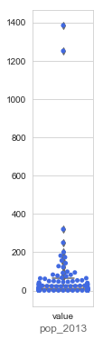

```python
# sélection de 'pop_2013'
sns.set_style("whitegrid")
plt.figure(figsize=(1.2,6))
#plt.title("pop_var", fontsize=12, color = 'navy')
plt.xlabel("pop_2013",color='dimgrey', size=12)

# plot 'pop_2013'
sns.boxplot(data=p1,width =0.7, color="tan")
sns.swarmplot(data=p1, color="royalblue")

plt.savefig('img/P5.1_boxplot1.png', dpi=120, bbox_inches='tight')

plt.show()
plt.close()
```

#### pop_var

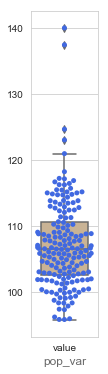

```python
# sélection de 'pop_var'
sns.set_style("whitegrid")
plt.figure(figsize=(1.2,6))
#plt.title("pop_var", fontsize=12, color = 'navy')
plt.xlabel("pop_var",color='dimgrey', size=12)

# plot 'pop_var'
sns.boxplot(data=p2,width =0.7, color="tan")
sns.swarmplot(data=p2, color="royalblue")

plt.savefig('img/P5.1_boxplot2.png', dpi=120, bbox_inches='tight')

plt.show()
plt.close()
```

#### prot_ani_ratio

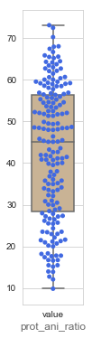

```python
# sélection de 'prot_ani_ratio'
sns.set_style("whitegrid")
plt.figure(figsize=(1.2,6))
#plt.title("pop_var", fontsize=12, color = 'navy')
plt.xlabel("prot_ani_ratio",color='dimgrey', size=12)

# plot 'prot_ani_ratio'
sns.boxplot(data=p3,width =0.7, color="tan")
sns.swarmplot(data=p3, color="royalblue")

plt.savefig('img/P5.1_boxplot3.png', dpi=120, bbox_inches='tight')

plt.show()
plt.close()
```

#### prot_g_cap_day

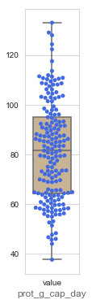

```python
# sélection de 'prot_g_cap_day'
sns.set_style("whitegrid")
plt.figure(figsize=(1.2,6))
#plt.title("pop_var", fontsize=12,prot_g_cap_daylor = 'navy')
plt.xlabel("prot_g_cap_day",color='dimgrey', size=12)

# plot 'prot_g_cap_day'
sns.boxplot(data=p4,width =0.7, color="tan")
sns.swarmplot(data=p4, color="royalblue")

plt.savefig('img/P5.1_boxplot4.png', dpi=120, bbox_inches='tight')

plt.show()
plt.close()
```

#### food_kcal_cap_day

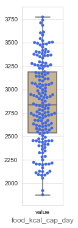

```python
# sélection de 'food_kcal_cap_day'
sns.set_style("whitegrid")
plt.figure(figsize=(1.2,6))
#plt.title("pop_var", fontsize=12,prot_g_cap_daylor = 'navy')
plt.xlabel("food_kcal_cap_day",color='dimgrey', size=12)

# plot 'food_kcal_cap_day'
sns.boxplot(data=p5, width =0.7, color="tan")
sns.swarmplot(data=p5, color="royalblue")

plt.savefig('img/P5.1_boxplot5.png', dpi=120, bbox_inches='tight')

plt.show()
plt.close()
```

### Variables personnelles

```python
# import des données du 'df_mini'
q = pd.read_csv('data/df_maxi.csv')
# supression des valeurs déjà exprimées dans 'df_mini'
q.drop(['pop_2013','pop_var','food_kcal_cap_day','prot_g_cap_day','prot_ani_ratio'], axis=1, inplace = True)
q.describe()
```

|  | gdp_2013 | edb_2019 | poultry_food_kg_cap_y | poultry_import_ratio |
| --- | --- | --- | --- | --- |
| count | 164.0 | 164.0 | 164.0 | 164.0 |
| mean | 14,104.7 | 63.7 | 20.3 | 38.1 |
| std | 19,645.9 | 12.4 | 16.4 | 41.1 |
| min | 314.7 | 30.6 | 0.4 | 0.0 |
| 25% | 1,832.7 | 55.1 | 6.4 | 3.5 |
| 50% | 6,093.5 | 63.3 | 18.2 | 26.0 |
| 75% | 15,801.9 | 73.7 | 27.6 | 67.4 |
| max | 113,341.2 | 86.6 | 73.4 | 264.1 |

```python
q.sort_values(by=['poultry_import_ratio'], inplace=True, ascending=False)
q.head()
```

|  | country | gdp_2013 | edb_2019 | poultry_food_kg_cap_y | poultry_import_ratio |
| --- | --- | --- | --- | --- | --- |
| 60 | China, Hong Kong SAR | 38,566.7 | 84.2 | 54.8 | 264.1 |
| 160 | Belgium | 46,713.5 | 74.0 | 12.2 | 176.2 |
| 102 | Netherlands | 51,466.5 | 76.0 | 23.9 | 132.4 |
| 143 | Oman | 21,268.8 | 67.2 | 31.4 | 103.5 |
| 45 | Djibouti | 1,553.2 | 62.0 | 2.3 | 100.0 |

```python
# melt : pivot des variables dans une colonne 'measure' et 'value'
pivot2=q.melt(id_vars=['country'], var_name='measure')
pivot2.reset_index()
pivot2.head(2)
```

|  | country | measure | value |
| --- | --- | --- | --- |
| 0 | China, Hong Kong SAR | gdp_2013 | 38,566.7 |
| 1 | Belgium | gdp_2013 | 46,713.5 |

```python
# création d'un df par variable
q1=pivot2.groupby('measure').get_group('gdp_2013')
q2=pivot2.groupby('measure').get_group('edb_2019')
q3=pivot2.groupby('measure').get_group('poultry_food_kg_cap_y')
q4=pivot2.groupby('measure').get_group('poultry_import_ratio')
```

#### gdp_2013

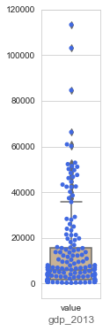

```python
# sélection de 'gdp_2013'
sns.set_style("whitegrid")
plt.figure(figsize=(1.2,6))
#plt.title("pop_var", fontsize=12, color = 'navy')
plt.xlabel("gdp_2013",color='dimgrey', size=12)

# plot 'pop_2013'
sns.boxplot(data=q1,width =0.7, color="tan")
sns.swarmplot(data=q1, color="royalblue")

plt.savefig('img/P5.1_boxplot6.png', dpi=120, bbox_inches='tight')

plt.show()
plt.close()
```

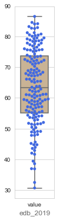

```python
# sélection de 'gdp_2013'
sns.set_style("whitegrid")
plt.figure(figsize=(1.2,6))
#plt.title("pop_var", fontsize=12, color = 'navy')
plt.xlabel("edb_2019",color='dimgrey', size=12)

# plot 'pop_2013'
sns.boxplot(data=q2,width =0.7, color="tan")
sns.swarmplot(data=q2, color="royalblue")

plt.savefig('img/P5.1_boxplot7.png', dpi=120, bbox_inches='tight')

plt.show()
plt.close()
```

#### poultry_food_kg_cap_y

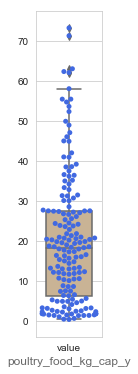

```python
# sélection de 'poultry_food_kg_cap_y'
sns.set_style("whitegrid")
plt.figure(figsize=(1.2,6))
#plt.title("pop_var", fontsize=12, color = 'navy')
plt.xlabel("poultry_food_kg_cap_y",color='dimgrey', size=12)

# plot 'pop_2013'
sns.boxplot(data=q3,width =0.7, color="tan")
sns.swarmplot(data=q3, color="royalblue")

plt.savefig('img/P5.1_boxplot8.png', dpi=120, bbox_inches='tight')

plt.show()
plt.close()
```

#### poultry_import_ratio

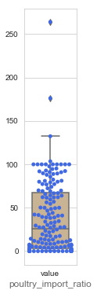

```python
# sélection de 'poultry_food_kg_cap_y'
sns.set_style("whitegrid")
plt.figure(figsize=(1.2,6))
#plt.title("pop_var", fontsize=12, color = 'navy')
plt.xlabel("poultry_import_ratio",color='dimgrey', size=12)

# plot 'pop_2013'
sns.boxplot(data=q4,width =0.7, color="tan")
sns.swarmplot(data=q4, color="royalblue")

plt.savefig('img/P5.1_boxplot9.png', dpi=120, bbox_inches='tight')

plt.show()
plt.close()
```